# Lab 3

Cameron Wonchoba

2/9/20

## Overview

During this lab, we will be generating "random" data and running a one-way ANOVA test on the categorical variables. Additionally, we be generating more "random" data and running a Tukey test on the data.

### Definitions:

#### ANOVA test:

A one-way ANOVA test is used to see if there is a statistical difference between the means of three or more groups. The null hypothesis assumes that all means are equal to each other. Thus, a rejection of the null hypothesis indicates that there is a stastical difference between the means of atleast one of the groups.

#### F-Test and F-statistic:

The F-Test is used to measure how spread out data is accross 3 or more data sets. The F-statistic is the ratio of "between-groups" variance and "with-group" variance.

**between-group variance:** The average is calculated of all groups and the variance of those averages is calculated.

**within-groups variance:** This measures the variance within each group.

The F-Statistic = between-group variance / within-groups variance. If this value is equal or close to 1, then this indicates that our null hypthosis is not rejected (all means are equal).

#### Bonferroni correction

When doing pair-wise comparisons, we increase our chance of observing a rare event (and also the chance of incorrectly rejecting the null hypothesis). The Bonferroni correction tests each hypothesis at a significance level of alpha/m - (alpha = level of significance, m = the number of hypotheses).

#### Tukey Test

They Tukey test is used to find means that are different from each other. We may use the tukey test when we run the ANOVA test and see that we have different means. Running the ANOVA test does not tell us which means are different from each other - only that there are some different means. The Tukey test will help identifiy the outliers.

## Data

Data is randomly generated. The data consists of voters age and race.

```python
import numpy as np
import pandas as pd
import matplotlib.pyplot as plt
import scipy.stats as stats
```

```python
np.random.seed(12)

races =   ["asian","black","hispanic","other","white"]

# Generate random data
voter_race = np.random.choice(a= races,
                              p = [0.05, 0.15 ,0.25, 0.05, 0.5],
                              size=1000)

voter_age = stats.poisson.rvs(loc=18,
                              mu=30,
                              size=1000)

# Group age data by race
voter_frame = pd.DataFrame({"race":voter_race,"age":voter_age})
groups = voter_frame.groupby("race").groups

# Etract individual groups
asian = voter_age[groups["asian"]]
black = voter_age[groups["black"]]
hispanic = voter_age[groups["hispanic"]]
other = voter_age[groups["other"]]
white = voter_age[groups["white"]]
```

## Exploratory Data Analysis

Generate a boxplot of the voter age of each race. According to the box above, the mean age of each race looks very similar to each other.

```
asian            AxesSubplot(0.1,0.679412;0.363636x0.220588)
black       AxesSubplot(0.536364,0.679412;0.363636x0.220588)
hispanic         AxesSubplot(0.1,0.414706;0.363636x0.220588)
other       AxesSubplot(0.536364,0.414706;0.363636x0.220588)
white                AxesSubplot(0.1,0.15;0.363636x0.220588)
dtype: object
```

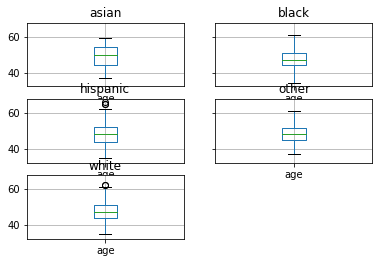

```python
# Generate boxplot.
voter_frame.groupby("race").boxplot()
```

### One way ANOVA test on data:

When splitting up the data into groups corresponding to their race, we run a One Way Anova test. This is used to test whether the means of each group are similar or unsimilar.

```python
# Perform the ANOVA
stats.f_oneway(asian, black, hispanic, other, white)
```

```
F_onewayResult(statistic=1.7744689357329695, pvalue=0.13173183201930463)
```

#### Results

The pvalue is 0.13, which is greater than 0.05. As a result, we will not reject the null hypothsis and conclude with a 95% confidence level that the mean voting age across the different races are roughly the same.

## Now let's make new age data where the group means do differ and run a second ANOVA:

## Data

Data is generated randomly, however, the white groups data is generated in a different way.

```python
np.random.seed(12)

# Generate random data
voter_race = np.random.choice(a= races,
                              p = [0.05, 0.15 ,0.25, 0.05, 0.5],
                              size=1000)

# Use a different distribution for white ages
white_ages = stats.poisson.rvs(loc=18,
                              mu=32,
                              size=1000)

voter_age = stats.poisson.rvs(loc=18,
                              mu=30,
                              size=1000)

voter_age = np.where(voter_race=="white", white_ages, voter_age)

# Group age data by race
voter_frame = pd.DataFrame({"race":voter_race,"age":voter_age})
groups = voter_frame.groupby("race").groups

# Extract individual groups
asian = voter_age[groups["asian"]]
black = voter_age[groups["black"]]
hispanic = voter_age[groups["hispanic"]]
other = voter_age[groups["other"]]
white = voter_age[groups["white"]]
```

## Data Exploratory/ Analysis

```
F_onewayResult(statistic=10.164699828386366, pvalue=4.5613242113994585e-08)
```

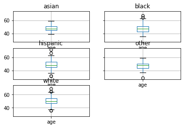

```python
# Generate boxplot.
voter_frame.groupby("race").boxplot()

# Perform the ANOVA
stats.f_oneway(asian, black, hispanic, other, white)
```

#### Results

We generate a box plot of the ages and races once again. We still see that the means seem roughly similar to each other.

However, we get a pvalue of 4.5*10^-8 which indicates that we should reject the null hypthosis as a 99% confidence level. This means that atleast one of the means is different from each other.

## T-test for each pair of groups

```python
# Get all race pairs
race_pairs = []

for race1 in range(4):
    for race2  in range(race1+1,5):
        race_pairs.append((races[race1], races[race2]))

# Conduct t-test on each pair
for race1, race2 in race_pairs:
    print(race1, race2)
    print(stats.ttest_ind(voter_age[groups[race1]],
                          voter_age[groups[race2]]))
```

```
asian black
Ttest_indResult(statistic=0.838644690974798, pvalue=0.4027281369339345)
asian hispanic
Ttest_indResult(statistic=-0.42594691924932293, pvalue=0.6704669004240726)
asian other
Ttest_indResult(statistic=0.9795284739636, pvalue=0.3298877500095151)
asian white
Ttest_indResult(statistic=-2.318108811252288, pvalue=0.020804701566400217)
black hispanic
Ttest_indResult(statistic=-1.9527839210712925, pvalue=0.05156197171952594)
black other
Ttest_indResult(statistic=0.28025754367057176, pvalue=0.7795770111117659)
black white
Ttest_indResult(statistic=-5.379303881281835, pvalue=1.039421216662395e-07)
hispanic other
Ttest_indResult(statistic=1.5853626170340225, pvalue=0.11396630528484335)
hispanic white
Ttest_indResult(statistic=-3.5160312714115376, pvalue=0.0004641298649066684)
other white
Ttest_indResult(statistic=-3.763809322077872, pvalue=0.00018490576317593065)
```

#### Results of t-test for each pair of groups

The test shows a really small pvalue for every group compared to the white group. This indicates that the white group may have a differing mean.

## Tukey Test

Multiple Comparison of Means - Tukey HSD, FWER=0.05

| group1 | group2 | meandiff | p-adj | lower | upper | reject |
| --- | --- | --- | --- | --- | --- | --- |
| asian | black | -0.8032 | 0.9 | -3.4423 | 1.836 | False |
| asian | hispanic | 0.4143 | 0.9 | -2.1011 | 2.9297 | False |
| asian | other | -1.0645 | 0.8852 | -4.2391 | 2.11 | False |
| asian | white | 1.9547 | 0.175 | -0.4575 | 4.3668 | False |
| black | hispanic | 1.2175 | 0.2318 | -0.386 | 2.821 | False |
| black | other | -0.2614 | 0.9 | -2.7757 | 2.253 | False |
| black | white | 2.7579 | 0.001 | 1.3217 | 4.194 | True |
| hispanic | other | -1.4789 | 0.4391 | -3.863 | 0.9053 | False |
| hispanic | white | 1.5404 | 0.004 | 0.3468 | 2.734 | True |
| other | white | 3.0192 | 0.0028 | 0.7443 | 5.2941 | True |

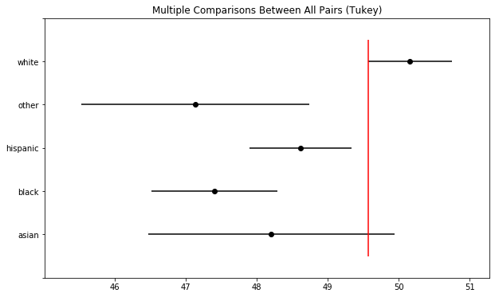

```python
from statsmodels.stats.multicomp import pairwise_tukeyhsd

tukey = pairwise_tukeyhsd(endog=voter_age,     # Data
                          groups=voter_race,   # Groups
                          alpha=0.05)          # Significance level

tukey.plot_simultaneous()    # Plot group confidence intervals
plt.vlines(x=49.57,ymin=-0.5,ymax=4.5, color="red")

tukey.summary()              # See test summary
```

#### Tukey Results

In every pair where we should reject the null hypothesis, the white group is included. This indicates that the white group has a mean that may be considered an outlier.

## Conclusions

The one way ANOVA test is good for testing differences in sample means. However, it does not reveal specific information about which sample may be differing.

There are two methods (described here), that help us identify the outlier means. First, we can perform a t-test for every group combination. Second, we can perform a Tukey test. Both reveal information to the user about which group is most significant.

Here, we learned that the white group was most significantly different, (from both the tukey test and the t-tests).